# Transcritical bifurcation

We now shift our attention to transcritical bifurcations. In this kind of bifurcation, there is change of stability characteristics of the equilibrium points, i.e. the stable branch becomes unstable and vice-versa as the parameter of the problem is changed.

```matlab
set(0, "defaultlinelinewidth", 5);
set (0, "defaulttextfontname", "TimesNewRoman")
set (0, "defaulttextfontsize", 20)
set (0, "DefaultAxesFontName", "TimesNewRoman")
set(0, 'DefaultAxesFontSize', 20)
```

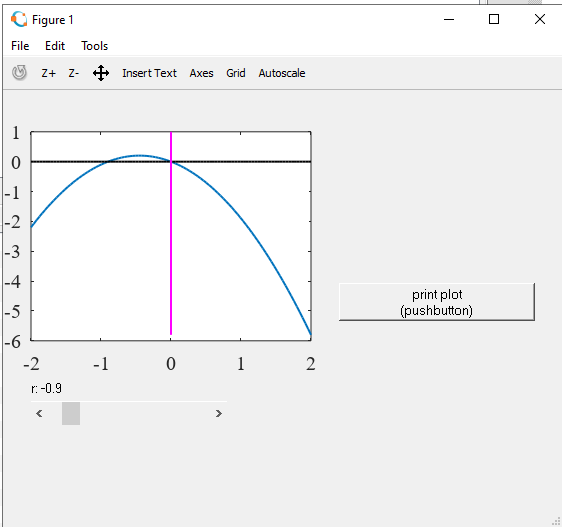

```matlab
set(0, "defaultlinelinewidth", 2);
set (0, "defaulttextfontname", "TimesNewRoman")
set (0, "defaulttextfontsize", 20)
set (0, "DefaultAxesFontName", "TimesNewRoman")
set(0, 'DefaultAxesFontSize', 20)

clear;
clc; close all;

h.ax = axes ("position", [0.05 0.4 0.5 0.5]);  #reduce plot windows size to accomodate sliders

function update_plot (obj, init = false)
  ## gcbo holds the handle of the control
  h = guidata (obj);
  replot = false;
  recalc = false;
  switch (gcbo)                       # If we make any change then we replot
    case {h.print_pushbutton}
      fn =  uiputfile ("*.png");
      print (fn);
    case {h.slider1}
      recalc = true;
    end

    if (recalc || init)
      r = -1 + 1*get (h.slider1, "value");
      set (h.label1, "string", sprintf ("r: %.1f", r));
      x = linspace(-2,2);
      xd = r*x - x.^2;
      h.plot = plot(x, xd, x, 0.*x, '-k', [0,0], [min(xd), 1], '-m');


      guidata (obj, h);
    else
      set (h.plot, "ydata", y);
    end
  end

  # specify the GUI plot properties like sliders and label formatting

  ## print figure
  h.print_pushbutton = uicontrol ("style", "pushbutton",
  "units", "normalized",
  "string", "print plot\n(pushbutton)",
  "callback", @update_plot,
  "position", [0.6 0.45 0.35 0.09]);
  ## guess
  h.label1 = uicontrol ("style", "text",
  "units", "normalized",
  "string", "Guess:",
  "horizontalalignment", "left",
  "position", [0.05 0.25 0.35 0.08]);

  h.slider1 = uicontrol ("style", "slider",
  "units", "normalized",
  "string", "slider",
  "callback", @update_plot,
  "value", 0.1,
  "position", [0.05 0.20 0.35 0.06]);



  set (gcf, "color", get(0, "defaultuicontrolbackgroundcolor"))
  guidata (gcf, h)
  update_plot (gcf, true);
```

In the above interactive widget (when you run the script in octave directly), we have plotted the function $rx-x^2$, where $r$ can be changed interactively. This shows the presence of two roots (except when $r = 0$) and the slope at the fixed root seems to change as $r$ crosses the origin. This behaviour of the function is at the heart of the transcritical bifurcation.

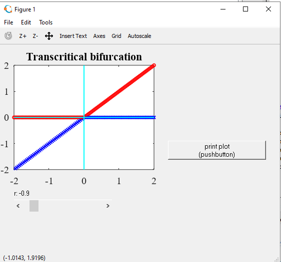

```matlab
function y = f(x, r)
    y = r*x- x.^2;
end
function dy = dfdx(x, r)
    dy = r-2*x;
end
x = linspace(-2, 2); r_a = linspace(-2, 2);

for r = r_a
    [sol, fval, info]= fsolve(@(x) f(x, r), [-2;2]);
    if info == 1 # Solution has convered
        for i = 1:length(sol)
            root = sol(i);
            slope_at_root = dfdx(root, r);
            if slope_at_root > 0
                plot(r, root, 'bx')
            else
                plot(r, root, 'ro')
                hold on
            end
        end
    end
end
xlim([min(r_a) max(r_a)])

line ([min(r_a) max(r_a)], [0 0], "linestyle", "-", "color", "c");
line ([0 0], [min(r_a) max(r_a)],"linestyle", "-", "color", "c");
xlabel("r");
ylabel("x*");
title("Transcritical bifurcation");
```

The above plot depicts the fixed points and also their stability as the parameter $r$ is varied.

Let's now consider another equation $$\dot{x} = x(1-x^2) - a(1-\exp(-bx))$$. This equation, as can be shown with a bit of manipulation, also has the same normal form as the equation which we discussed above.

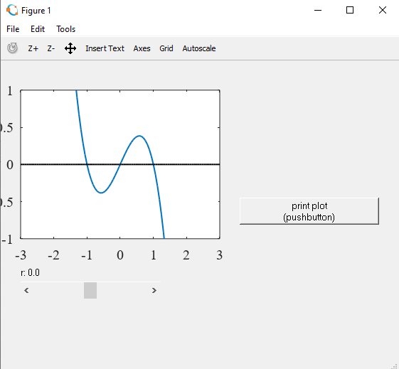

```matlab
set(0, "defaultlinelinewidth", 2);
set (0, "defaulttextfontname", "TimesNewRoman")
set (0, "defaulttextfontsize", 20)
set (0, "DefaultAxesFontName", "TimesNewRoman")
set(0, 'DefaultAxesFontSize', 20)

clear;
clc; close all;

h.ax = axes ("position", [0.05 0.4 0.5 0.5]);  #reduce plot windows size to accomodate sliders

function update_plot (obj, init = false)
  ## gcbo holds the handle of the control
  h = guidata (obj);
  replot = false;
  recalc = false;
  switch (gcbo)                       # If we make any change then we replot
    case {h.print_pushbutton}
      fn =  uiputfile ("*.png");
      print (fn);
    case {h.slider1}
      recalc = true;
    end

    if (recalc || init)
      r = -2 + 4*get (h.slider1, "value");
      set (h.label1, "string", sprintf ("r: %.1f", r));
      x = linspace(-3,3);
      a = 1;
      xd = x.*(1-x.^2) - a*(1-exp(-r*x));
      h.plot = plot(x, xd, x, 0.*x, '-k');
      ylim([-1 1]);

      guidata (obj, h);
    else
      set (h.plot, "ydata", y);
    end
  end

  # specify the GUI plot properties like sliders and label formatting

  ## print figure
  h.print_pushbutton = uicontrol ("style", "pushbutton",
  "units", "normalized",
  "string", "print plot\n(pushbutton)",
  "callback", @update_plot,
  "position", [0.6 0.45 0.35 0.09]);
  ## guess
  h.label1 = uicontrol ("style", "text",
  "units", "normalized",
  "string", "Guess:",
  "horizontalalignment", "left",
  "position", [0.05 0.25 0.35 0.08]);

  h.slider1 = uicontrol ("style", "slider",
  "units", "normalized",
  "string", "slider",
  "callback", @update_plot,
  "value", 0.5,
  "position", [0.05 0.20 0.35 0.06]);



  set (gcf, "color", get(0, "defaultuicontrolbackgroundcolor"))
  guidata (gcf, h)
  update_plot (gcf, true);
```

We now plot the bifurcation diagram

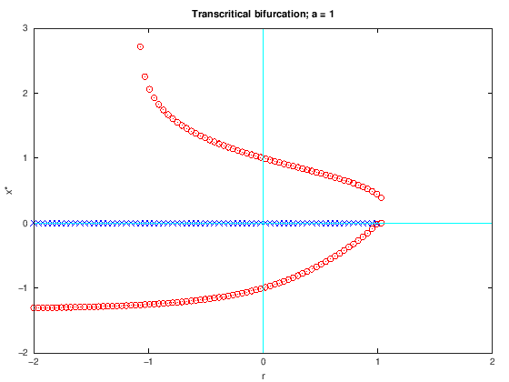

```matlab
function y = f(x, r)
    y = x.*(1-x.^2) - (1-exp(-r*x));
end

function dy = dfdx(x, r)
    dy = 1-3*x.^2 -r*exp(-r*x);
end
x = linspace(-2, 2);
r_a = linspace(-2, 2);

for r = r_a
    [sol, fval, info]= fsolve(@(x) f(x, r), [-2;1;0;-1;2]);
    if info == 1 # Solution has convered
        for i = 1:length(sol)
            root = sol(i);
            slope_at_root = dfdx(root, r);
            if slope_at_root > 0
                plot(r, root, 'bx')
            else
                plot(r, root, 'ro')
                hold on
            end
        end
    end
end

xlim([min(r_a) max(r_a)])
ylim([-2 3])
line ([min(r_a) max(r_a)], [0 0], "linestyle", "-", "color", "c");
line ([0 0], [-10 10],"linestyle", "-", "color", "c");
xlabel("r");
ylabel("x*");
title("Transcritical bifurcation; a = 1");
```

Let's now consider an equation with two parameters. The presence of two parameters implies that changing the two parameters might lead to the changing of the stable points and their stabilty. The snippet below shows how the two parameters can be passed to a function and then how the main snipped can use two loops over the parameter space to draw the bifurcation diagram in 2D.

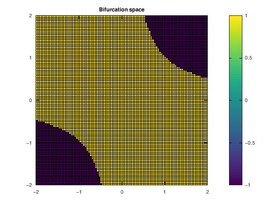

```matlab
1;
function y = f(x, a, b)
    y = x.*(1-x.^2) - a*(1-exp(-b*x));
end
function dy = dfdx(x, a, b)
    dy = 1-3*x.^2 -a*b*exp(-b*x);
end
epsilon = 1e-8;
a = linspace(-2, 2, 100);
b = linspace(-2, 2, 100);
[A, B] = meshgrid(a, b);
C = 100*ones(size(A));

for i =1:length(a)
    for j =1:length(b)
        [sol, fval, info]= fsolve(@(x) f(x, a(i), b(i)), 0);
        if info == 1 # Solution has converged
            roots = sol;
            zeroroot = roots(roots<=0+epsilon && roots >=-epsilon) ;
            sign_slope_zeroroot = sign(dfdx(zeroroot, a(i), b(j)));
            #print(sign_slope_zeroroot)
            C(j,i) = sign_slope_zeroroot;
        end
    end
end
pcolor(A, B, C); colorbar();
title("Bifurcation space");
```